# Chapter 8. Significance tests

통계적 추정의 한 가지 방법은 모수치에 대해 신뢰구간을 구하는 것이었습니다. 유의성 검정(significance test) 혹은 가설 검정(test of hypothesis)은 다른 방법입니다.

- 영가설: Null Hypothesis ($H_0$)
- 대립가설: Alternative Hypothesis ($H_A$)

책에서 범죄에 대한 판결을 예로 들었는데, 보통 무죄 추정의 원칙을 지키니까 영가설은 "*피고인은 죄가 없다*" 가 될 것입니다. 대립 가설은 "*피고인은 죄가 있다*" 겠네요.

대립 가설은 입증을 위한 것이 아닙니다. 입증하는 것은 영가설을 기각할 수 있는 지 아닌 지의 여부입니다. 말이 좀 이상하긴 한데, 판사가 내릴 수 있는 결론은 제출된 증거들을 고려할 때

1) 피고인은 죄가 없다라는 가설은 기각되어야 한다

2) 피고인은 죄가 없다라는 가설은 기각될 만큼 극단적이지는 않다.

의 두 가지입니다. 피고인은 죄가 있다, 라는 가설은 영가설이 기각되고 난 다음에야 의미가 있는 것이라고 할 수 있겠습니다. 법정에서의 증거가 아닌 통계에서의 증거는 **검정 통계량(test statistic)**이 구해지는 실험 결과입니다. 이렇게 말했으니 검정 통계량도 확률 변수임을 잊지 마시기 바랍니다. 실험을 하는 것은 모집단에서 표본을 하나 추출하는 것과 같은 이치이겠지요?

이전 스터디에 잠깐 언급했었지만, 결국 영가설이 있고, 이 영가설을 기준으로 할 때 검정 통계량이 갖는 값이 내가 계산한 검정 통계량이거나 그 이상일 확률이 곧 **p-value** 입니다. 그리고 이 p-value를 계산하는 과정을 유의성 검정이라고 합니다.

$$p-value~=~P(test ~statistic ~is ~the ~observed ~value ~or ~is ~more~extreme|H_0)$$

p-value는 우리가 관찰한 값이 영가설과 차이 나는 정도가 단순한 sampling variation(표본을 좀 잘못 추출해서 생기는 오차) 혹은 우연으로 인한 것인지, 아니면 정말로 영가설을 기각해야 하는 것인지를 알려줍니다. p-value가 *작으면* 검정 통계치가 **통계적으로 유의미하다(statistically significant)** 라는 표현을 씁니다.

p-value가 크거나 작다고 말하기 위해서는 기준이 필요합니다. 그 기준을 두고 **유의 수준(significance level)**이라고 합니다. 일반적으로 유의 수준은 0.05로 잡습니다. p-value가 이보다 작을 경우에는 영가설은 기각되어 참이 아닌 것으로 판명됩니다. 반대로 p-value가 유의 수준보다 클 경우에는 영가설이 기각되지 않습니다.

중요한 것은 영가설을 기각하거나 기각하지 못한다고 해서 우리가 영가설의 참/거짓을 밝히는 것은 아니라는 사실입니다. 영가설을 기각하는 것은 영가설을 받아들일 경우 우리가 한 실험을 통해 얻은 검정 통계량보다 더 극단적인 값을 관찰할 확률이 거의 없다는 뜻이고, 영가설을 기각하지 못하는 것은 영가설이 참이라는 뜻이 아니라 우리가 관찰한 통계량이 영가설이 기각될만큼 극단적인 값이 아니라는 이야기입니다. 영가설의 참/거짓은 확인할 방도가 없습니다. 이 역시 모집단의 성질이기 때문입니다.

유의 수준을 정하게 되면, 검정 통계량의 어떤 값들이 영가설을 기각하게끔 하는 지 구할 수 있습니다. 이를 통해 **기각역(rejection region)**을 정의할 수 있게 됩니다. 기각역은 검정 통계량이 가질 수 있는 값들 중 유의 수준보다 더 작은 p-value가 계산되는 값들로 구성되어 있습니다. 이 기각역을 나누는 경계들을 critical values 라고 합니다. 예를 들면 표준정규분포에서 95%의 확률 변수 값들이 분포할 구간이 [-1.96 1.96] 라고 했는데, 바로 -1.96, 1.96이 critical values인 셈이 되겠습니다. 그러면 기각역은 [-$\infty$, -1.96), (1.96, $\infty$]가 될 것입니다 (양측 검정의 경우). 그러나 대부분 기각역을 표시하기 보다는 p-value를 보고하는 것이 일반적입니다.

영가설의 기각에 대한 결정이 우리가 구한 검정 통계량에 의해 이뤄지기 때문에, 결정이 항상 옳은 것은 아닙니다. 사실은 우리의 검정 통계량이 좀 극단적인 표본에 의해서 구해졌기 때문에 *사실은 영가설을 기각할 수 없는 데도 기각하는 경우*가 생길 수 있습니다. 이를 두고 **Type 1 error** 라고 합니다. 이와 반대로 *사실은 영가설을 기각해야 하는 데도 기각을 하지 못하는 경우*도 생길 수 있습니다. 이를 두고 **Type 2 error** 라고 합니다.

Example 8.2는 평균을 비교하는 내용입니다. 예를 들어 기계가 영점이 잘 맞춰져 있다고 할 때 기계가 출력하는 값이라는 확률 변수 X가 Normal(0,1)을 따른다고 가정하겠습니다. 그러면 영가설은 다음과 같이 표현할 수 있습니다.

$H_0: \mu = 0$

또한 영점이 빗나간 경우에는 기계가 출력하는 값이 Normal(1,1)을 따른다고 합니다.

$H_A: \mu = 1$

이제 한 번 관찰한 기계의 출력 값을 통해 기계가 영점이 맞았는 지 그렇지 않은 지를 어떻게 판단할 수 있을까요? 예를 들면 0.7이라는 값을 관찰했다고 해 보겠습니다. 이건 영가설을 기각할 수 있는 값일까요?

위에서 말한 p-value를 생각해 보겠습니다. 우선 N(0,1) 이라는 분포에서 P(-$\infty \leq X \leq 0.7$)를 구해보겠습니다.

```r
pnorm(0.7,0,1)
```

0.758036347776927

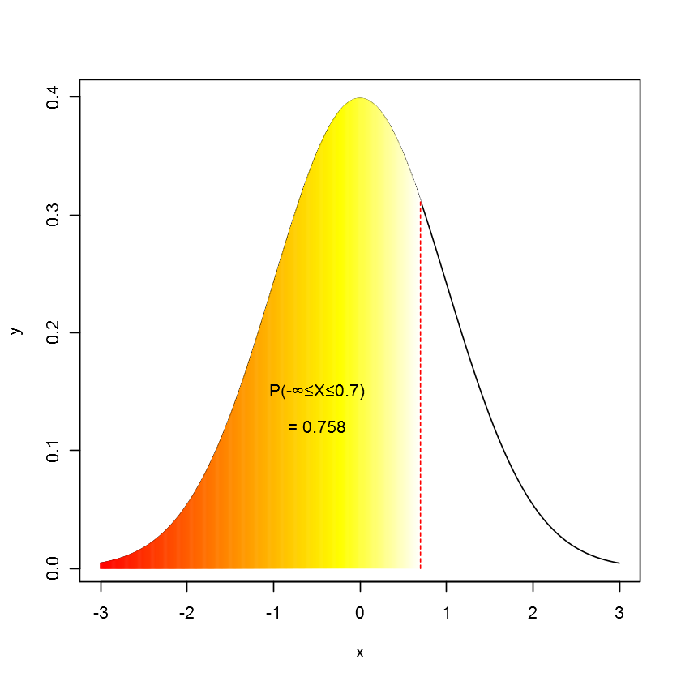

```r
x <- seq(-3,3,0.01)
y <- dnorm(x, 0, 1)
plot(x,y, type='l')
x.shade <- seq(-3, 0.7, 0.01)
l <- length(x.shade)
color <- heat.colors(l)
for (i in 1:l)
{
    polygon(c(x.shade[i],rev(x.shade[i])),c(dnorm(x.shade[i],0,1),
                                            0.001*dnorm(rev(x.shade[i]),0,1)),
            border=color[i],col=NA)
}
symbol<-"\u2264"
symbol2 <- "\u221E"
text(-0.5, 0.15, bquote(P*'(-'* .(symbol2) * .(symbol) * X * .(symbol) * "0.7)"))
text(-0.5, 0.12, "= 0.758")
lines(c(0.7, 0.7), c(0, dnorm(0.7,0,1)), lty=2, col=2)
```

자, 이제 0.7 이상의 값이 나올 확률은 전체 확률인 1에서 0.758을 빼면 될 것입니다.

```r
1-0.758
```

0.242

고로, 0.7이라는 값이 발견 되었을 때 이 값 이상의 값들을 영가설 - N(0,1) - 을 바탕으로 관찰할 수 있을 확률은 24.2% 입니다. p-value가 충분히 작지 않기 때문에(0.05 이하) 영가설을 기각할 수 없습니다.

만약 대립가설에 따른다면 0.7이라는 값은 어떤 의미를 가질까요?

```r
pnorm(0.7, 1, 1)
```

0.382088577811047

대립가설, 곧 N(1,1) 에서 0.7, 혹은 그 이하의 값을 관찰할 확률은 0.382 입니다. 이 역시 충분히 작은 p-value가 아니기 때문에 0.7이라는 값은 곧 N(0,1)에서도 충분히 관찰될 수 있는 값이고, N(1,1)에서도 충분히 관찰될 수 있는 값입니다. 특히 0.7은 0보다는 1에 더 가깝습니다. 그렇지만 이것이 N(0,1)을 기각하고 N(1,1)을 채택하게 만들만큼 결정적인 증거는 아닙니다.

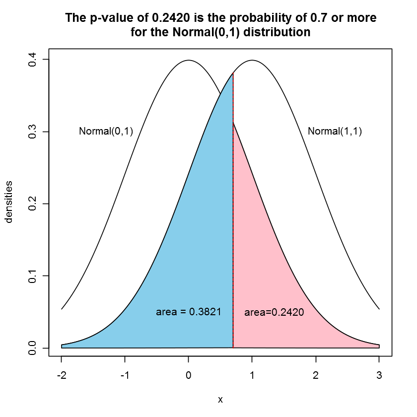

```r
x <- seq(-2,3,0.01)
y1 <- dnorm(x,0,1)
y2 <- dnorm(x,1,1)
x.shade1 <- seq(-2,0.7,0.01)
x.shade2 <- seq(0.7, 3, 0.01)
plot(x,y1, type='l', ylab="densities", main="The p-value of 0.2420 is the probability of 0.7 or more\nfor the Normal(0,1) distribution")
lines(x,y2)
polygon(c(x.shade1,rev(x.shade1)),c(dnorm(x.shade1,1,1),
                                            0.001*dnorm(rev(x.shade1),1,1)),
            col="skyblue")
polygon(c(x.shade2,rev(x.shade2)),c(dnorm(x.shade2,0,1),
                                            0.001*dnorm(rev(x.shade2),0,1)),
            col="pink")

lines(c(0.7, 0.7), c(0, dnorm(0.7,1,1)), lty=2, col=2)
text(-1.3, 0.3, "Normal(0,1)")
text(2.3,0.3, "Normal(1,1)")
text(0, 0.05, "area = 0.3821")
text(1.35,0.05, "area=0.2420")
```

문제는 지금 두 분포의 평균이 너무 가까워서 0.7 이라는 특정 확률 변수 값이 어느 분포에서 나왔는지 알아보기 힘들다는 것입니다. 그러므로

1) 분포의 평균이 좀 더 차이가 많이 나거나

2) 두 분포의 표준편차 값이 줄어서 평균이 0인 분포의 확률 변수 값들은 0 근처로 더욱 몰리고, 평균이 1인 분포의 확률 변수 값들은 1 근처로 더욱 몰려서 0.7 이라는 값이 더욱 평균 1인 분포에서 나올 확률이 높아지게 하고 평균 0인 분포에서 나올 확률이 낮아지게 하면 영가설의 기각이 더욱 쉬워질 것입니다.

우리는 표본 평균의 표준편차가 $\frac{\sigma}{\sqrt{n}}$ 이라는 것을 알고 있습니다. $\sigma$는 모집단의 표준편차입니다. 표본 평균의 표준편차를 갖는 분포를 만들면 2)에 해당하는 방식으로 좀 더 구분이 확실해 질 것입니다.

그래서 이제 단일 관찰 값이 아니라, 표본 평균($\bar{X}$)을 우리의 검정 통계량으로 삼겠습니다. 표본의 크기는 n=10 입니다. 기계가 출력한 10개의 값이 평균 0.7일 때와 단일 출력 값이 0.7인 것은 별 차이가 없으니까요.

E($\bar{X}$) = $\mu$ 이고, 영가설($H_0: \mu = 0$)에 따라 검정 통계량은 N(0, $\frac{1}{\sqrt{10}}$) 이라는 분포를 따를 것입니다. $\bar{X} \geq 0.7$에 해당하는 p-value는 어떻게 구할까요?

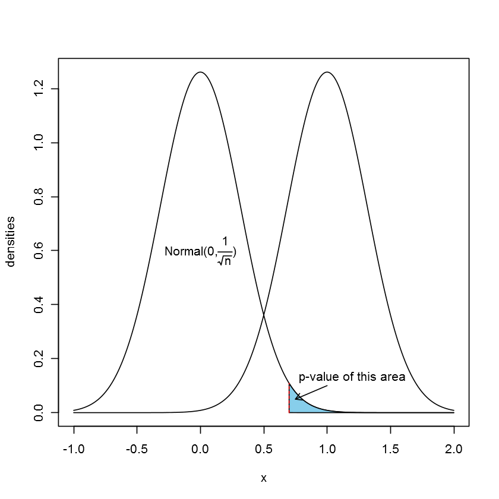

```r
x <- seq(-1,2,0.01)
y1 <- dnorm(x, 0, 1/sqrt(10))
y2 <- dnorm(x, 1, 1/sqrt(10))
plot(x,y1, ylab="densities", type='l')
lines(x, y2)
x.shade <- seq(0.7, 2, 0.01)
polygon(c(x.shade, rev(x.shade)), c(dnorm(x.shade,0,1/sqrt(10)),0.001*dnorm(rev(x.shade),0,1/sqrt(10))),
       col="skyblue")
lines(c(0.7, 0.7), c(0, dnorm(0.7, 0, 1/sqrt(10))), lty=2, col=2)
text(0, 0.6, expression(paste("Normal(0,", frac(1,sqrt(n)),")")))
arrows(1,0.1,0.75, 0.05, code=2, length=0.1)
text(1.2, 0.13, "p-value of this area")
```

```r
# P(-inf<=X<=0.7)
pnorm(0.7, 0, 1/sqrt(10))
```

0.986571652246238

```r
# P(0.7<X<=inf) = 1-P(-inf<=X<=0.7)
1-pnorm(0.7, 0, 1/sqrt(10))
```

0.0134283477537622

그래서 p-value는 0.0134가 됩니다. 단 한 번 관찰하는 것 보다, 10번 관찰해서 계산한 표본 평균을 검정 통계량으로 삼아 표본 평균의 표집 분포(sampling distribution)를 살펴 보는 것이, 단일 관찰 값을 검정 통계량으로 삼아서 관찰 값의 모집단 분포를 가정하는 것 보다 더 효과적임을 알 수 있습니다. 책의 211페이지 머리부분에 나온 The steps involved in finding the p-value를 읽어 보시기 바랍니다.